# a3_task3_karla_garibay

Karla Garibay Garcia

11/1/2020

## Summary: In this document, I will be using version control, project management and data wranging, analysis and visualization skills to explore red and purple urchin data (urchins.csv) recorded by Santa Barbara Coastal Long Term Ecological Research program divers.

## Attach packages

Here, I attach tidyverse, janitor, here, kableExtra, and lubridate packages in the setup code chunk.

## Read in data

Here, I read in the urchins.csv data from the data folder.

```r
urchins.csv <- read.csv(here("data", "urchins.csv"))
```

## Clean up data

Here, I use clean_names() to switch all column names into lower_snake_case.

```r
urchins_clean <- urchins.csv %>% clean_names()
```

## Section 1: Size comparisons of purple and red urchins

### i. Exploratory data visualization

Here, I use a faceted histrogram and boxplot to compare the distribution of sizes between purple and red urchins.

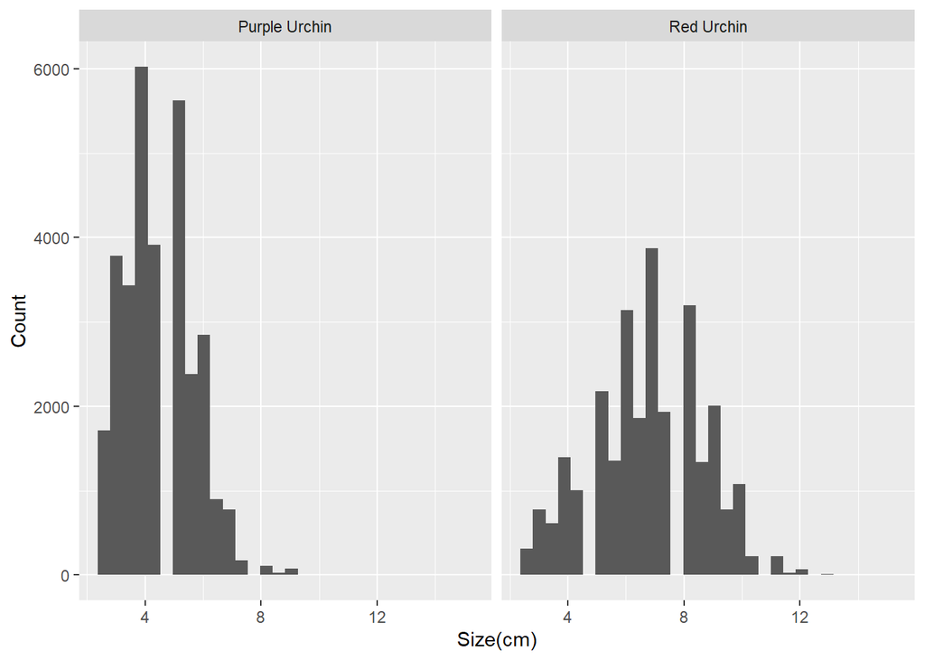

```r
ggplot(data = urchins_clean,
       aes(x = size)) +
  geom_histogram(bins = 30) +
  labs(x = "Size(cm)",
       y = "Count") +
  facet_wrap(~common_name)
```

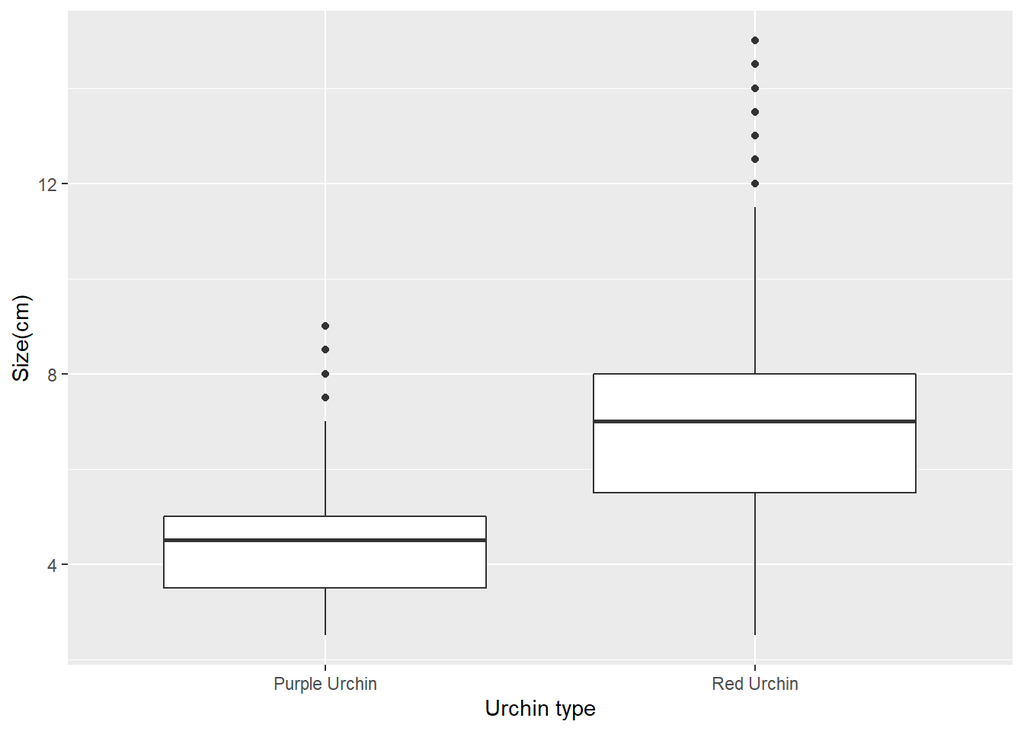

```r
ggplot(data = urchins_clean,
       aes(x = common_name,
           y = size)) +
  geom_boxplot() +
  labs(x = "Urchin type",
       y = "Size(cm)")
```

### ii. Descriptive statistics table

Here, I create a summary table that contains the mean, median, standard deviation, and sample size statistics for purple and red urchins.

```r
urchin_stats <- urchins_clean %>%
  group_by(common_name) %>%
  summarise(mean_size = mean(size),
            median_size = median(size),
            sd_size = sd(size),
            n = n())

urchin_stats %>%
  kbl() %>%
  kable_styling()
```

| common_name | mean_size | median_size | sd_size | n |
| --- | --- | --- | --- | --- |
| Purple Urchin | 4.469797 | 4.5 | 1.175264 | 31805 |
| Red Urchin | 6.776489 | 7.0 | 1.891343 | 27408 |

## Section 2: Exploring purple urchin counts by size and year

### i. Data wrangling

Here, I create a stored subset of the urchins data called purple_urchins that:

- Only retains observations for purple urchins
- Converts the date to class “Date”
- Contains a new column that only contains the year
- Contains a new column called site_full that contains the full name for each of the 5 sites

```r
purple_urchins <- urchins_clean %>%
  filter(common_name == "Purple Urchin") %>%
  mutate(date_new = mdy(date)) %>%
  mutate(year = year(date_new)) %>%
  mutate(site_full = case_when(
    site %in% "NAPL" ~ "Naples Reef",
    site %in% "AQUE" ~ "Arroyo Quemado Reef",
    site %in% "CARP" ~ "Carpinteria Reef",
    site %in% "MOHK" ~ "Mohawk Reef",
    site %in% "IVEE" ~ "Isla Vista Reef"))
```

### ii. Descriptive statistics table

Here, I create a summary table containing the total number of purple urchins observed by site and year.

```r
purple_stats <- purple_urchins %>%
  count(site, year)
```

### iii. Exploratory data visualization

Here, I use a faceted histrogram to compare the distribution of counts of purple sea urchins recorded at each site over time for the years included in the study.

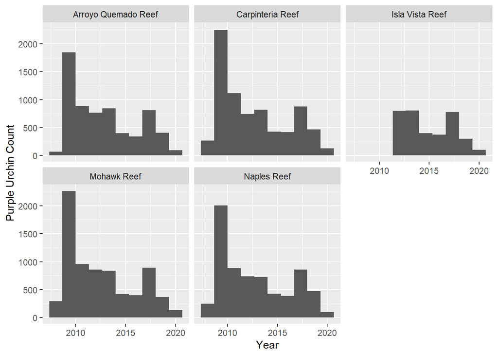

```r
ggplot(data = purple_urchins,
       aes(x = year)) +
  geom_histogram(bins = 10) +
  labs(x = "Year",
       y = "Purple Urchin Count") +
  facet_wrap(~site_full)
```